# Multivariate Time Series Analysis of Air Quality in Delhi

Aleksandr Jan Smoliakov

2025-05-16

# 1. Introduction

Urban air pollution arises from complex interactions among multiple pollutants. This report analyzes hourly air quality measurements from India, focusing on Delhi for a detailed multivariate time series investigation. We employ techniques to understand dynamic dependencies, test for stationarity and causality, model these interactions, and generate forecasts. Our period of interest is 2018-2019.

# 2. Data Loading and Preprocessing

## 2.1. Load Packages

```r
library(readr)
library(dplyr)
library(ggplot2)
library(tidyr)
library(lubridate)
library(forecast)
library(urca)
# library(vars) # For VAR, Granger, IRF, FEVD
library(MTS) # For VARMA
library(corrplot)

# setwd("/home/aleks/msc-studies/multivariate_time_series/project")
```

## 2.2. Import Data and Initial Filtering

```r
aq_data_full <- read_csv("../data/input/city_hour.csv")

pollutants <- c("PM2.5", "PM10", "NO2", "CO", "NH3")

aq_data_filtered <- aq_data_full %>%
  filter(
    Datetime >= "2018-01-01" & Datetime < "2020-01-02"
  ) %>%
  select(
    Datetime, City, all_of(pollutants)
  ) %>%
  mutate(
    year = year(Datetime)
  )

glimpse(aq_data_filtered)
```

```
## Rows: 334,468
## Columns: 8
## $ Datetime <dttm> 2017-12-31 22:00:00, 2017-12-31 23:00:00, 2018-01-01 00:00:0…
## $ City     <chr> "Ahmedabad", "Ahmedabad", "Ahmedabad", "Ahmedabad", "Ahmedaba…
## $ PM2.5    <dbl> 111.77, 98.10, 78.43, 77.60, 74.23, 63.43, 64.57, 67.87, 64.5…
## $ PM10     <dbl> NA, NA, NA, NA, NA, NA, NA, NA, NA, NA, NA, NA, NA, NA, NA, N…
## $ NO2      <dbl> 91.35, 78.25, 126.91, 105.18, 71.65, 62.14, 64.52, 66.83, 97.…
## $ CO       <dbl> 6.23, 5.42, 23.79, 7.71, 5.13, 5.36, 5.04, 5.34, 5.66, 6.50, …
## $ NH3      <dbl> NA, NA, NA, NA, NA, NA, NA, NA, NA, NA, NA, NA, NA, NA, NA, N…
## $ year     <dbl> 2017, 2017, 2018, 2018, 2018, 2018, 2018, 2018, 2018, 2018, 2…
```

## 2.3. Handling Missing Values

```r
# Missingness percentage by variable and city
missing_pct <- aq_data_filtered %>%
  group_by(City) %>%
  summarise(across(all_of(pollutants), ~ sum(is.na(.)) / n() * 100), .groups = "drop")
print(missing_pct)
```

```
## # A tibble: 23 × 6
##    City           PM2.5   PM10     NO2      CO     NH3
##    <chr>          <dbl>  <dbl>   <dbl>   <dbl>   <dbl>
##  1 Ahmedabad     5.43   70.7    4.35    4.24   100
##  2 Amaravati    18.3    17.6   17.4    18.1     17.8
##  3 Amritsar     19.6    10.0   11.4    14.7     11.4
##  4 Bengaluru     3.31    4.91   0.861   0.0228  18.5
##  5 Bhopal        0.900   0.939  0.743   1.10     0.782
##  6 Brajrajnagar 28.5    24.7   25.9    19.1     26.7
##  7 Chandigarh   19.5     7.03  17.1     2.26    21.6
##  8 Chennai       0.0342 80.5    0.0399  0.0342   5.71
##  9 Coimbatore   18.5    17.5    7.29    2.03    19.2
## 10 Delhi         0       0      0       0        0
## # ℹ 13 more rows
```

```r
# We may go for Delhi or Bhopal, as they have the least missing values (under 1%).

# Filter cities with high missingness and impute for others
cities_to_exclude <- c("Ahmedabad", "Gurugram", "Lucknow", "Patna")
aq_data_imputed <- aq_data_filtered %>%
  filter(!City %in% cities_to_exclude) %>%
  group_by(City) %>%
  mutate(across(
    all_of(pollutants),
    ~ forecast::na.interp(.) # Linear interpolation for missing values
  )) %>%
  ungroup()

# Verify imputation
sum(is.na(aq_data_imputed %>% select(all_of(pollutants))))
```

```
## [1] 0
```

## 2.4. Data Transformation (Log1p)

Pollutant series are non-negative and often right-skewed. A log1p transformation ($log(1+x)$) helps stabilize variance, normalize distributions, and handle potential zero values.

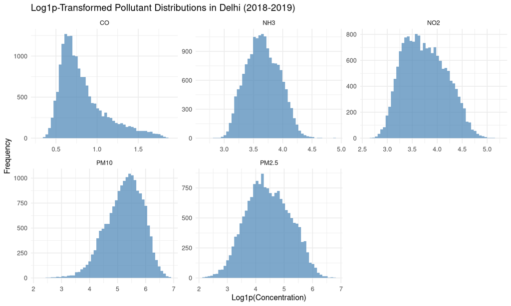

```r
aq_data_transformed <- aq_data_imputed %>%
  mutate(across(
    all_of(pollutants),
    ~ log1p(.)
  ))

# Visualize distributions post-transformation for a sample city (Delhi)
aq_long_delhi_transformed <- aq_data_transformed %>%
  filter(City == "Delhi") %>%
  select(Datetime, all_of(pollutants)) %>%
  pivot_longer(-Datetime, names_to = "pollutant", values_to = "value")

ggplot(aq_long_delhi_transformed, aes(x = value)) +
  geom_histogram(bins = 50, fill = "steelblue", alpha = 0.7) +
  facet_wrap(~pollutant, scales = "free") +
  labs(title = "Log1p-Transformed Pollutant Distributions in Delhi (2018-2019)", x = "Log1p(Concentration)", y = "Frequency") +
  theme_minimal()
```

## 2.5. Focus on Sample City (Delhi) and Daily Aggregation

For detailed modeling, we focus on Delhi and aggregate hourly data to daily means to reduce noise and computational load for certain models.

```r
sample_city <- "Delhi"
aq_city_hourly <- aq_data_transformed %>% filter(City == sample_city)

aq_city_daily <- aq_city_hourly %>%
  mutate(date = as_date(Datetime)) %>%
  group_by(date) %>%
  summarize(across(all_of(pollutants), mean, na.rm = TRUE), .groups = "drop")

# Convert to time series object for modeling
ts_aq_city_daily <- ts(aq_city_daily %>% select(all_of(pollutants)),
  start = c(year(min(aq_city_daily$date)), yday(min(aq_city_daily$date))),
  frequency = 365
) # Approximate for daily data, or 1 if irregular

glimpse(ts_aq_city_daily)
```

```
##  Time-Series [1:732, 1:5] from 2018 to 2020: 5.97 5.7 5.62 5.36 5.46 ...
##  - attr(*, "dimnames")=List of 2
##   ..$ : NULL
##   ..$ : chr [1:5] "PM2.5" "PM10" "NO2" "CO" ...
```

# 3. Exploratory Data Analysis (Delhi - Daily Data)

## 3.1. Time Series Plots

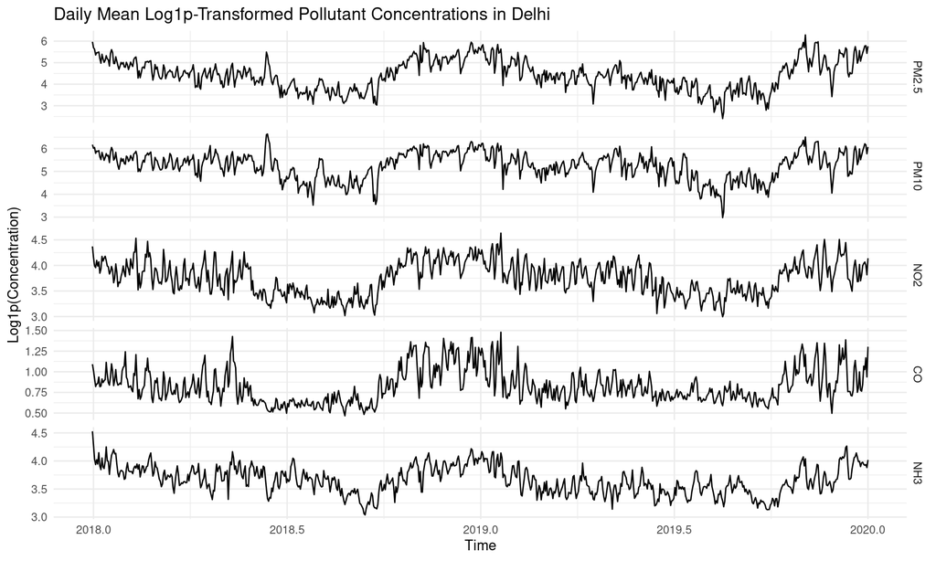

```r
autoplot(ts_aq_city_daily, facets = TRUE) +
  labs(
    title = paste("Daily Mean Log1p-Transformed Pollutant Concentrations in", sample_city),
    x = "Time", y = "Log1p(Concentration)"
  ) +
  theme_minimal()
```

## 3.2. Correlation Analysis

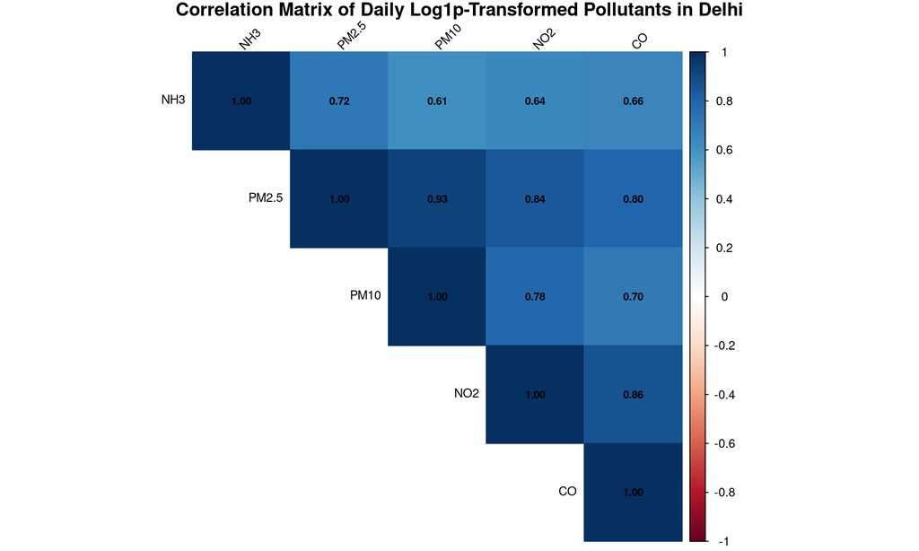

```r
corr_matrix_daily <- cor(na.omit(ts_aq_city_daily))
corrplot(
  corr_matrix_daily,
  method = "color", type = "upper", order = "hclust",
  tl.col = "black", tl.srt = 45, tl.cex = 0.8,
  addCoef.col = "black", number.cex = 0.7,
  cl.cex = 0.8,
  title = "Correlation Matrix of Daily Log1p-Transformed Pollutants in Delhi",
  mar = c(0, 0, 1, 0)
)
```

**Observation:** In the daily data, all pollutants are positively correlated, with PM2.5 and PM10 showing the strongest correlation (0.93).

## 3.3. Seasonal Decomposition

Air quality data typically exhibits strong seasonality. We can decompose a key series like PM2.5 using STL (Seasonal and Trend decomposition using Loess) to visualize these components.

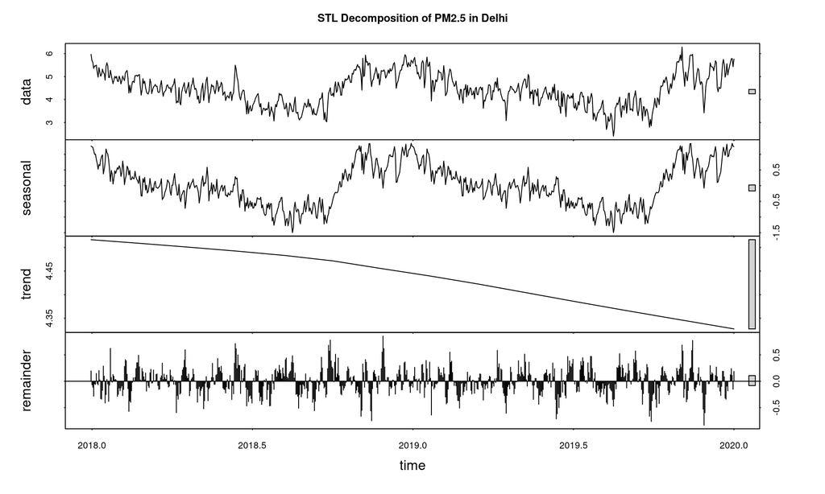

```r
for (pollutant in c("PM2.5")) {
  stl_plot <- stl(ts_aq_city_daily[, pollutant], s.window = "periodic")
  plot(stl_plot, main = paste("STL Decomposition of", pollutant, "in Delhi"))
}
```

**Typical Finding:** Strong annual seasonality is often visible, with higher pollution in winter months and lower levels during monsoon/summer. Weekly patterns related to human activity might also be present. This underscores the importance of addressing seasonality in modeling.

# 4. Stationarity and Cointegration Analysis (Delhi - Daily Data)

## 4.1. Augmented Dickey-Fuller (ADF) Tests

We test for unit roots in the levels of (log1p-transformed, daily mean) pollutant series.

```r
adf_results_daily <- data.frame(
  pollutant = colnames(ts_aq_city_daily),
  statistic = numeric(ncol(ts_aq_city_daily)),
  p_value_approx = character(ncol(ts_aq_city_daily)), # More direct p-value if package allows
  is_stationary_5pct = logical(ncol(ts_aq_city_daily))
)

for (i in seq_along(colnames(ts_aq_city_daily))) {
  series <- ts_aq_city_daily[, pollutants[i]]
  # Using type="drift" as an example, "trend" could also be considered
  test <- ur.df(series, type = "drift", selectlags = "AIC")
  adf_results_daily$statistic[i] <- test@teststat[1]
  # ur.df doesn't give p-value directly, compare test stat with critical values
  adf_results_daily$is_stationary_5pct[i] <- test@teststat[1] < test@cval[1, "5pct"]
  adf_results_daily$p_value_approx[i] <- ifelse(test@teststat[1] < test@cval[1, "1pct"], "<0.01",
    ifelse(test@teststat[1] < test@cval[1, "5pct"], "<0.05",
      ifelse(test@teststat[1] < test@cval[1, "10pct"], "<0.10", ">0.10")
    )
  )
}
print(adf_results_daily)
```

```
##   pollutant statistic p_value_approx is_stationary_5pct
## 1     PM2.5 -5.874020          <0.01               TRUE
## 2      PM10 -7.267671          <0.01               TRUE
## 3       NO2 -7.986455          <0.01               TRUE
## 4        CO -8.680929          <0.01               TRUE
## 5       NH3 -7.558551          <0.01               TRUE
```

**Result:** For all pollutants, the ADF test statistic is highly negative, and the p-value is <0.01. Consequently, `is_stationary_5pct` is TRUE for all series. We conclude that all series are stationary (I(0)).

# 5. Multivariate Time Series Modeling (Delhi - Daily Data)

## 5.1. VAR (Vector Autoregression) Model

Series are I(0), so we can fit a VAR model directly on the levels. If series are I(1), we would first difference them.

### 5.1.1. Lag Order Selection for VAR

We select the optimal lag order `p` for the VAR model.

```r
# Determine optimal lag order
var_select <- vars::VARselect(ts_aq_city_daily, lag.max = 30, type = "const") # Max 30 days for daily data
print(var_select$selection)
```

```
## AIC(n)  HQ(n)  SC(n) FPE(n)
##      4      2      1      4
```

```r
optimal_p <- var_select$selection["AIC(n)"] # Or SC(n)/BIC
print(paste("Selected lag order (AIC) for VAR:", optimal_p))
```

```
## [1] "Selected lag order (AIC) for VAR: 4"
```

### 5.1.2. VAR Model Fitting

```r
var_model <- vars::VAR(ts_aq_city_daily, p = optimal_p, type = "const")
summary(var_model)
```

```
##
## VAR Estimation Results:
## =========================
## Endogenous variables: PM2.5, PM10, NO2, CO, NH3
## Deterministic variables: const
## Sample size: 728
## Log Likelihood: 2622.895
## Roots of the characteristic polynomial:
## 0.9689 0.881 0.881 0.7683 0.6946 0.5874 0.5874 0.5639 0.5639 0.491 0.491 0.479 0.4263 0.4263 0.3445 0.3357 0.3357 0.3348 0.3117 0.3117
## Call:
## vars::VAR(y = ts_aq_city_daily, p = optimal_p, type = "const")
##
##
## Estimation results for equation PM2.5:
## ======================================
## PM2.5 = PM2.5.l1 + PM10.l1 + NO2.l1 + CO.l1 + NH3.l1 + PM2.5.l2 + PM10.l2 + NO2.l2 + CO.l2 + NH3.l2 + PM2.5.l3 + PM10.l3 + NO2.l3 + CO.l3 + NH3.l3 + PM2.5.l4 + PM10.l4 + NO2.l4 + CO.l4 + NH3.l4 + const
##
##          Estimate Std. Error t value Pr(>|t|)
## PM2.5.l1  0.82170    0.10355   7.935 8.23e-15 ***
## PM10.l1  -0.08447    0.09191  -0.919 0.358360
## NO2.l1    0.40227    0.10514   3.826 0.000142 ***
## CO.l1     0.35751    0.16791   2.129 0.033588 *
## NH3.l1   -0.70509    0.12187  -5.786 1.09e-08 ***
## PM2.5.l2 -0.03453    0.12858  -0.269 0.788376
## PM10.l2   0.06648    0.11823   0.562 0.574075
## NO2.l2   -0.23261    0.12488  -1.863 0.062920 .
## CO.l2    -0.65076    0.20289  -3.207 0.001400 **
## NH3.l2    0.70247    0.16519   4.253 2.40e-05 ***
## PM2.5.l3  0.24927    0.12769   1.952 0.051322 .
## PM10.l3  -0.10539    0.11800  -0.893 0.372123
## NO2.l3   -0.11250    0.12534  -0.898 0.369753
## CO.l3     0.24489    0.20567   1.191 0.234192
## NH3.l3   -0.36506    0.16616  -2.197 0.028338 *
## PM2.5.l4  0.07141    0.10379   0.688 0.491630
## PM10.l4  -0.08982    0.09134  -0.983 0.325798
## NO2.l4    0.12406    0.10586   1.172 0.241602
## CO.l4    -0.09746    0.16788  -0.581 0.561743
## NH3.l4    0.19146    0.12004   1.595 0.111151
## const     0.72443    0.31513   2.299 0.021806 *
## ---
```

[output cut: 149 more lines]

```
## Covariance matrix of residuals:
##         PM2.5    PM10      NO2       CO      NH3
## PM2.5 0.08063 0.07311 0.030751 0.021720 0.018020
## PM10  0.07311 0.08025 0.027809 0.018172 0.014758
## NO2   0.03075 0.02781 0.027947 0.014711 0.009351
## CO    0.02172 0.01817 0.014711 0.012888 0.007403
## NH3   0.01802 0.01476 0.009351 0.007403 0.012516
##
## Correlation matrix of residuals:
##        PM2.5   PM10    NO2     CO    NH3
## PM2.5 1.0000 0.9089 0.6478 0.6738 0.5672
## PM10  0.9089 1.0000 0.5872 0.5651 0.4657
## NO2   0.6478 0.5872 1.0000 0.7752 0.5000
## CO    0.6738 0.5651 0.7752 1.0000 0.5829
## NH3   0.5672 0.4657 0.5000 0.5829 1.0000
```

## 5.2. VARMA (Vector Autoregressive Moving Average) Model

VARMA models generalize VARs by including MA terms, potentially offering more parsimonious models. They are fitted on level data (or stationary data).

```r
# Determining optimal p, q is very computationally intensive.
p_varma <- 1 # order$p
q_varma <- 1 # order$q

# Fit VARMA on levels (original log-transformed daily data)
varma_mod <- MTS::VARMA(ts_aq_city_daily, p = p_varma, q = q_varma, include.mean = TRUE)
```

```
## Number of parameters:  55
## initial estimates:  1.057 1.078 1.1863 0.4757 0.7308 1.2555 -0.2802 0.0447 -0.4765 -0.1354 0.3129 0.5848 0.1446 -0.4357 -0.1291 0.2542 -0.151 0.7907 -0.2561 -0.1439 0.1622 -0.0983 7e-04 0.6263 -0.102 0.1278 -0.0838 0.0306 -0.1249 0.7622 -0.4423 0.2047 0.3479 0.84 -0.5949 -0.2209 0.1365 0.2052 0.7…
## Par. lower-bounds:  0.3689 0.3973 0.7824 0.2029 0.4608 1.1171 -0.4037 -0.1719 -0.7687 -0.2871 0.176 0.4627 -0.0697 -0.7248 -0.2793 0.173 -0.2235 0.6636 -0.4276 -0.233 0.1073 -0.1473 -0.0852 0.5104 -0.1621 0.0735 -0.1322 -0.0544 -0.2395 0.7026 -0.6953 -0.0192 0.0444 0.3922 -0.8864 -0.4712 -0.085 -…
## Par. upper-bounds:  1.745 1.7587 1.5902 0.7485 1.0008 1.3938 -0.1568 0.2613 -0.1843 0.0164 0.4497 0.7069 0.3588 -0.1466 0.021 0.3354 -0.0786 0.9178 -0.0846 -0.0548 0.217 -0.0494 0.0865 0.7421 -0.0418 0.1821 -0.0354 0.1156 -0.0102 0.8217 -0.1893 0.4286 0.6515 1.2878 -0.3034 0.0294 0.3581 0.5055 1.…
## Final   Estimates:  1.057113 1.077668 1.186918 0.47467 0.7308168 1.256239 -0.2808854 0.04460039 -0.4764882 -0.1349151 0.3128976 0.5852535 0.144541 -0.4354694 -0.1292497 0.2541291 -0.1522018 0.7908754 -0.2574352 -0.1419493 0.1612906 -0.09775381 0.00130573 0.6266802 -0.1020993 0.1282572 -0.08162708…
##
## Coefficient(s):
##        Estimate  Std. Error  t value Pr(>|t|)
## PM2.5  1.057113    0.388085    2.724 0.006451 **
## PM10   1.077668    0.398680    2.703 0.006870 **
## NO2    1.186918    0.223661    5.307 1.12e-07 ***
## CO     0.474670    0.164201    2.891 0.003843 **
## NH3    0.730817    0.152346    4.797 1.61e-06 ***
## PM2.5  1.256239    0.075357   16.670  < 2e-16 ***
## PM10  -0.280885    0.066247   -4.240 2.24e-05 ***
## NO2    0.044600    0.126515    0.353 0.724440
## CO    -0.476488    0.179927   -2.648 0.008092 **
## NH3   -0.134915    0.087448   -1.543 0.122878
## PM2.5  0.312898    0.076017    4.116 3.85e-05 ***
## PM10   0.585254    0.066911    8.747  < 2e-16 ***
## NO2    0.144541    0.129641    1.115 0.264881
## CO    -0.435469    0.179609   -2.425 0.015328 *
## NH3   -0.129250    0.088613   -1.459 0.144680
## PM2.5  0.254129    0.044161    5.755 8.68e-09 ***
## PM10  -0.152202    0.040070   -3.798 0.000146 ***
## NO2    0.790875    0.071743   11.024  < 2e-16 ***
## CO    -0.257435    0.105421   -2.442 0.014607 *
## NH3   -0.141949    0.051446   -2.759 0.005795 **
## PM2.5  0.161291    0.031062    5.193 2.07e-07 ***
## PM10  -0.097754    0.027575   -3.545 0.000393 ***
## NO2    0.001306    0.052160    0.025 0.980028
## CO     0.626680    0.074335    8.430  < 2e-16 ***
## NH3   -0.102099    0.035563   -2.871 0.004092 **
## PM2.5  0.128257    0.030426    4.215 2.49e-05 ***
## PM10  -0.081627    0.026763   -3.050 0.002288 **
## NO2    0.029739    0.048130    0.618 0.536652
## CO    -0.123204    0.063641   -1.936 0.052877 .
## NH3    0.758798    0.033319   22.774  < 2e-16 ***
##       -0.439385    0.155683   -2.822 0.004768 **
##        0.209012    0.127526    1.639 0.101218
```

[output cut: 41 more lines]

```
## [2,] 0.2194 -0.138 -0.2060 -0.734 0.580
## [3,] 0.0752 -0.031  0.0204 -0.455 0.270
## [4,] 0.0754 -0.015 -0.1074 -0.181 0.132
## [5,] 0.1301 -0.066 -0.1323 -0.256 0.077
##
## Residuals cov-matrix:
##            [,1]       [,2]        [,3]        [,4]        [,5]
## [1,] 0.08432478 0.07577509 0.033106624 0.022498270 0.017562745
## [2,] 0.07577509 0.08191585 0.029778071 0.018835141 0.014368471
## [3,] 0.03310662 0.02977807 0.029144565 0.015118680 0.009216887
## [4,] 0.02249827 0.01883514 0.015118680 0.012937230 0.007314104
## [5,] 0.01756274 0.01436847 0.009216887 0.007314104 0.012667209
## ----
## aic=  -21.00243
## bic=  -20.65712
```

```r
print(summary(varma_mod))
```

```
##           Length Class  Mode
## data      3660   mts    numeric
## ARorder      1   -none- numeric
## MAorder      1   -none- numeric
## cnst         1   -none- logical
## coef        55   -none- numeric
## secoef      55   -none- numeric
## residuals 3655   -none- numeric
## Sigma       25   -none- numeric
## aic          1   -none- numeric
## bic          1   -none- numeric
## Phi         25   -none- numeric
## Theta       25   -none- numeric
## Ph0          5   -none- numeric
```

# 6. Model Applications and Diagnostics (from VAR Model)

## 6.1. Granger Causality

Tests whether past values of one pollutant help predict current values of another, given past values of all pollutants.

```r
# NO2 is a primary pollutant, often from traffic, and can Granger-cause CO, PM2.5, etc.
# Does NO2 Granger-cause other pollutants?
granger_no2_on_all <- vars::causality(var_model, cause = "NO2")
print("Granger causality from NO2 to other variables:")
```

```
## [1] "Granger causality from NO2 to other variables:"
```

```r
print(granger_no2_on_all$Granger)
```

```
##
##  Granger causality H0: NO2 do not Granger-cause PM2.5 PM10 CO NH3
##
## data:  VAR object var_model
## F-Test = 1.7453, df1 = 16, df2 = 3535, p-value = 0.03277
```

```r
# TODO To test for CO specifically if the above is for all:
# This requires more careful interpretation of the full output or a specific test setup.
# The output shows if NO2 Granger-causes EACH of the other variables.
```

**Interpretation:** The p-value of 0.033 indicates that NO2 Granger-causes other pollutants, suggesting that past values of NO2 help predict current values of PM2.5, PM10, CO, and NH3.

## 6.2. Impulse Response Functions (IRFs)

IRFs trace the effect of a one-time shock (typically one standard deviation) in one pollutant on current and future values of itself and other pollutants.

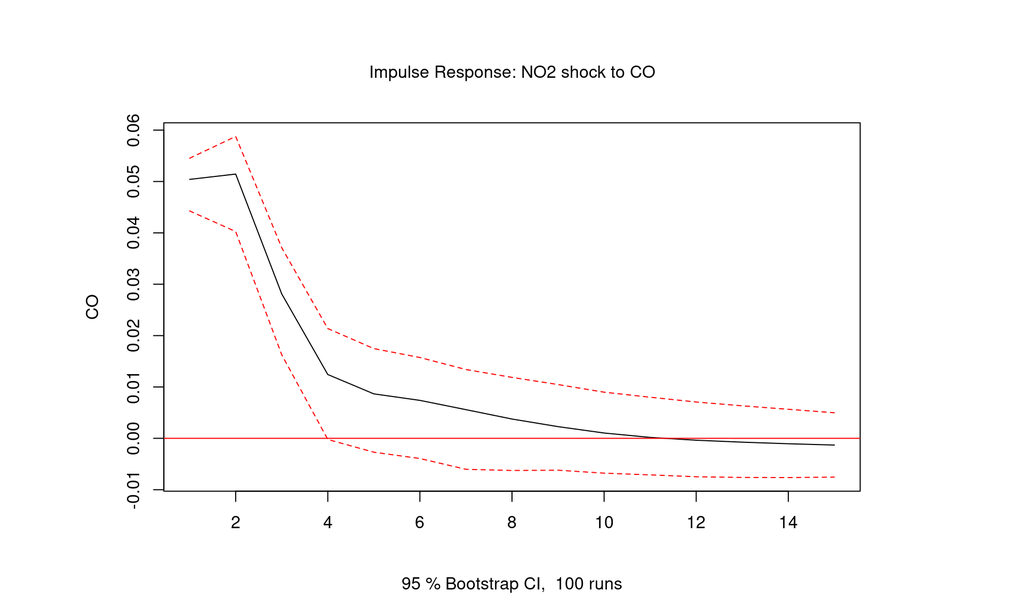

```r
# Example: Response of PM2.5 to a shock in NO2
irf_no2_to_co <- vars::irf(
  var_model,
  impulse = "NO2", # The variable receiving the shock
  response = "CO", # The variable whose response we observe
  n.ahead = 14, # Forecast horizon for the response (e.g., 14 days)
  boot = TRUE, # Use bootstrapping for confidence intervals
  ci = 0.95 # 95% confidence interval
)
plot(irf_no2_to_co, main = "Impulse Response: NO2 shock to CO")
```

**Insight:** IRFs can quantify the magnitude and duration of such inter-pollutant influences. A positive shock to NO2 leads to a temporary increase in CO.

## 6.3. Forecast Error Variance Decomposition (FEVD)

FEVD decomposes the forecast error variance of each pollutant into proportions attributable to shocks from itself and from other pollutants.

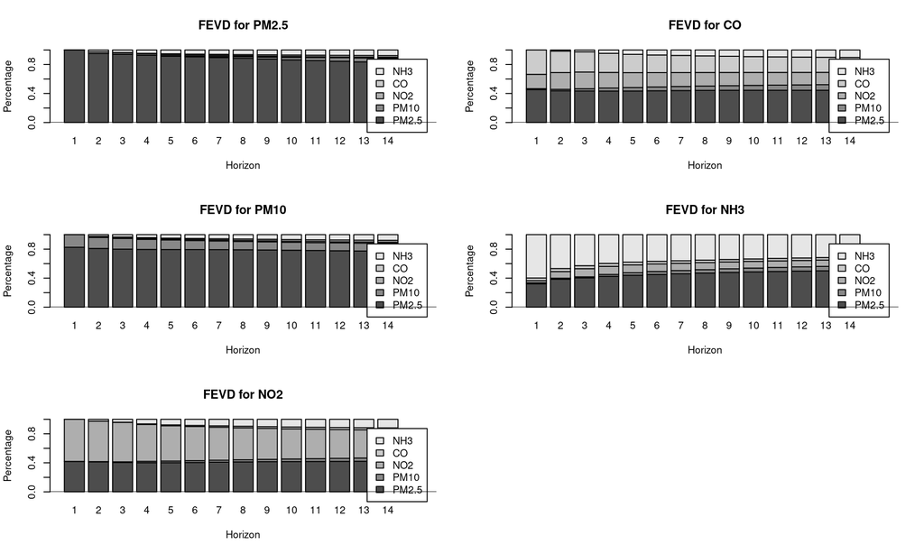

```r
fevd_var <- vars::fevd(var_model, n.ahead = 14) # Decompose for 14 days ahead
# Plot FEVD for a specific variable, e.g., PM2.5
plot(fevd_var)
```

**Insight:** FEVD shows the relative importance of different pollutants in driving the forecast uncertainty of a particular pollutant over time. A large proportion of other pollutants’ error variance is attributable to PM2.5, indicating its influence on the system.

# 7. Forecasting Comparison (Delhi - Daily PM2.5)

## 7.1. Data Splitting (Train/Test)

We split the daily data into a training set and a test set (e.g., last 14 days) to evaluate forecast accuracy.

```r
# Using the log-transformed daily data (levels) for y_levels
y_levels <- ts_aq_city_daily
total_obs <- nrow(y_levels)
forecast_horizon <- 14
train_len <- total_obs - forecast_horizon

train_levels <- window(y_levels, end = time(y_levels)[train_len])
test_levels <- window(y_levels, start = time(y_levels)[train_len + 1])
```

## 7.2. VAR Model Forecasting

```r
rmse_var_pm25 <- NA
fc_var_pm25_point <- NULL

var_model_train <- vars::VAR(train_levels, p = optimal_p, type = "const")
# predict() for varest automatically inverts to level forecasts
fc_var_list <- predict(var_model_train, n.ahead = forecast_horizon, ci = 0.95)

fc_var_pm25_point <- fc_var_list$fcst$PM2.5[, "fcst"]
rmse_var_pm25 <- sqrt(mean((test_levels[, "PM2.5"] - fc_var_pm25_point)^2, na.rm = TRUE))
```

## 7.3. VARMA Model Forecasting

```r
rmse_varma_pm25 <- NA
fc_varma_pm25_point <- NULL

varma_mod_train <- MTS::VARMA(train_levels, p = p_varma, q = q_varma, include.mean = TRUE)
```

```
## Number of parameters:  55
## initial estimates:  1.0538 1.0752 1.1958 0.4644 0.7177 1.2345 -0.2624 0.0478 -0.4415 -0.1463 0.2935 0.6022 0.1456 -0.4006 -0.1391 0.2588 -0.1498 0.7801 -0.2504 -0.1442 0.1584 -0.0939 0.003 0.6272 -0.1034 0.1225 -0.0807 0.0367 -0.1249 0.7613 -0.4513 0.2025 0.3395 0.8657 -0.5918 -0.226 0.1324 0.196…
## Par. lower-bounds:  0.3649 0.3934 0.7909 0.1942 0.445 1.091 -0.3867 -0.1725 -0.7322 -0.2981 0.1514 0.4792 -0.0724 -0.6882 -0.2893 0.1744 -0.2228 0.6507 -0.4212 -0.2334 0.1021 -0.1426 -0.0834 0.5132 -0.1629 0.0657 -0.1299 -0.0505 -0.2399 0.7013 -0.7068 -0.0215 0.0317 0.4148 -0.8838 -0.4788 -0.0894…
## Par. upper-bounds:  1.7428 1.757 1.6007 0.7347 0.9903 1.3781 -0.1381 0.2681 -0.1509 0.0055 0.4355 0.7252 0.3636 -0.113 0.0111 0.3431 -0.0767 0.9096 -0.0796 -0.055 0.2147 -0.0451 0.0894 0.7412 -0.0438 0.1793 -0.0316 0.1239 -0.0098 0.8214 -0.1958 0.4266 0.6473 1.3165 -0.2998 0.0268 0.3541 0.5009 1.…
## Final   Estimates:  1.053965 1.074788 1.196504 0.4631364 0.7177477 1.235591 -0.2631675 0.04757851 -0.4414544 -0.1457761 0.2935295 0.6026344 0.1455421 -0.4003289 -0.1391788 0.2587198 -0.1510894 0.7804075 -0.2522191 -0.1420362 0.1573752 -0.09340959 0.003820241 0.6275906 -0.1032692 0.1229966 -0.0781…
##
## Coefficient(s):
##        Estimate  Std. Error  t value Pr(>|t|)
## PM2.5   1.05397     0.38277    2.754 0.005895 **
## PM10    1.07479     0.39393    2.728 0.006364 **
## NO2     1.19650     0.22280    5.370 7.86e-08 ***
## CO      0.46314     0.16287    2.844 0.004460 **
## NH3     0.71775     0.15253    4.706 2.53e-06 ***
## PM2.5   1.23559     0.07773   15.895  < 2e-16 ***
## PM10   -0.26317     0.06616   -3.978 6.95e-05 ***
## NO2     0.04758     0.12608    0.377 0.705901
## CO     -0.44145     0.17704   -2.494 0.012648 *
## NH3    -0.14578     0.08678   -1.680 0.092971 .
## PM2.5   0.29353     0.07834    3.747 0.000179 ***
## PM10    0.60263     0.06682    9.019  < 2e-16 ***
## NO2     0.14554     0.12965    1.123 0.261601
## CO     -0.40033     0.17696   -2.262 0.023684 *
## NH3    -0.13918     0.08806   -1.580 0.114002
## PM2.5   0.25872     0.04589    5.638 1.73e-08 ***
## PM10   -0.15109     0.04058   -3.723 0.000197 ***
## NO2     0.78041     0.07148   10.918  < 2e-16 ***
## CO     -0.25222     0.10492   -2.404 0.016217 *
## NH3    -0.14204     0.05193   -2.735 0.006232 **
## PM2.5   0.15737     0.03207    4.908 9.21e-07 ***
## PM10   -0.09341     0.02775   -3.365 0.000764 ***
## NO2     0.00382     0.05164    0.074 0.941027
## CO      0.62759     0.07412    8.468  < 2e-16 ***
## NH3    -0.10327     0.03570   -2.892 0.003823 **
## PM2.5   0.12300     0.03164    3.888 0.000101 ***
## PM10   -0.07815     0.02706   -2.888 0.003881 **
## NO2     0.03574     0.04867    0.734 0.462703
## CO     -0.12253     0.06372   -1.923 0.054494 .
## NH3     0.75736     0.03358   22.556  < 2e-16 ***
##        -0.44768     0.15885   -2.818 0.004828 **
##         0.20789     0.12835    1.620 0.105305
```

[output cut: 41 more lines]

```
## [2,] 0.2236 -0.1345 -0.1976 -0.761 0.5791
## [3,] 0.0883 -0.0360  0.0166 -0.485 0.2756
## [4,] 0.0823 -0.0170 -0.0949 -0.220 0.1325
## [5,] 0.1323 -0.0687 -0.1236 -0.275 0.0812
##
## Residuals cov-matrix:
##            [,1]       [,2]        [,3]       [,4]        [,5]
## [1,] 0.08397852 0.07533171 0.032822092 0.02204393 0.017570221
## [2,] 0.07533171 0.08160783 0.029399194 0.01833135 0.014336189
## [3,] 0.03282209 0.02939919 0.029089610 0.01492765 0.009246281
## [4,] 0.02204393 0.01833135 0.014927649 0.01261482 0.007286170
## [5,] 0.01757022 0.01433619 0.009246281 0.00728617 0.012771035
## ----
## aic=  -21.00315
## bic=  -20.65259
```

```r
yf_varma_train_list <- MTS::VARMApred(varma_mod_train, h = forecast_horizon)
```

```
## Predictions at origin  718
##       PM2.5  PM10   NO2     CO   NH3
##  [1,] 4.907 5.369 3.814 0.8083 3.944
##  [2,] 4.954 5.434 3.868 0.8484 3.926
##  [3,] 4.982 5.480 3.904 0.8770 3.910
##  [4,] 4.996 5.513 3.928 0.8968 3.896
##  [5,] 5.000 5.534 3.942 0.9101 3.883
##  [6,] 4.995 5.546 3.949 0.9183 3.870
##  [7,] 4.985 5.552 3.952 0.9229 3.858
##  [8,] 4.970 5.552 3.950 0.9249 3.847
##  [9,] 4.953 5.549 3.947 0.9249 3.837
## [10,] 4.933 5.543 3.941 0.9235 3.827
## [11,] 4.913 5.534 3.935 0.9212 3.817
## [12,] 4.892 5.525 3.927 0.9183 3.808
## [13,] 4.870 5.514 3.920 0.9149 3.800
```

[output cut: 17 more lines]

```r
fc_varma_pm25_point <- yf_varma_train_list$pred[, "PM2.5"]
rmse_varma_pm25 <- sqrt(mean((test_levels[, "PM2.5"] - fc_varma_pm25_point)^2, na.rm = TRUE))
```

## 7.4. RMSE Comparison for PM2.5

```r
forecast_comparison <- data.frame(
  Model = c("VAR(4)", "VARMA(1, 1)"),
  RMSE_PM2.5 = c(rmse_var_pm25, rmse_varma_pm25)
)
print(forecast_comparison)
```

```
##         Model RMSE_PM2.5
## 1      VAR(4)  0.7209488
## 2 VARMA(1, 1)  0.6051992
```

**Result:** The RMSE values indicate the typical forecast error for each model on PM2.5. Lower RMSE suggests better accuracy.

```r
fc_all_pollutants <- MTS::VARMApred(varma_mod, h = forecast_horizon)
```

```
## Predictions at origin  732
##       PM2.5  PM10   NO2     CO   NH3
##  [1,] 5.785 6.115 4.182 1.2647 4.069
##  [2,] 5.642 5.994 4.130 1.1926 4.030
##  [3,] 5.534 5.908 4.096 1.1401 3.999
##  [4,] 5.449 5.846 4.072 1.1012 3.974
##  [5,] 5.381 5.799 4.055 1.0718 3.953
##  [6,] 5.325 5.764 4.042 1.0490 3.936
##  [7,] 5.277 5.736 4.031 1.0309 3.921
##  [8,] 5.235 5.713 4.021 1.0161 3.907
##  [9,] 5.197 5.693 4.011 1.0037 3.895
## [10,] 5.162 5.675 4.002 0.9929 3.884
## [11,] 5.129 5.658 3.993 0.9834 3.873
## [12,] 5.098 5.642 3.984 0.9748 3.864
## [13,] 5.068 5.627 3.975 0.9670 3.854
```

[output cut: 17 more lines]

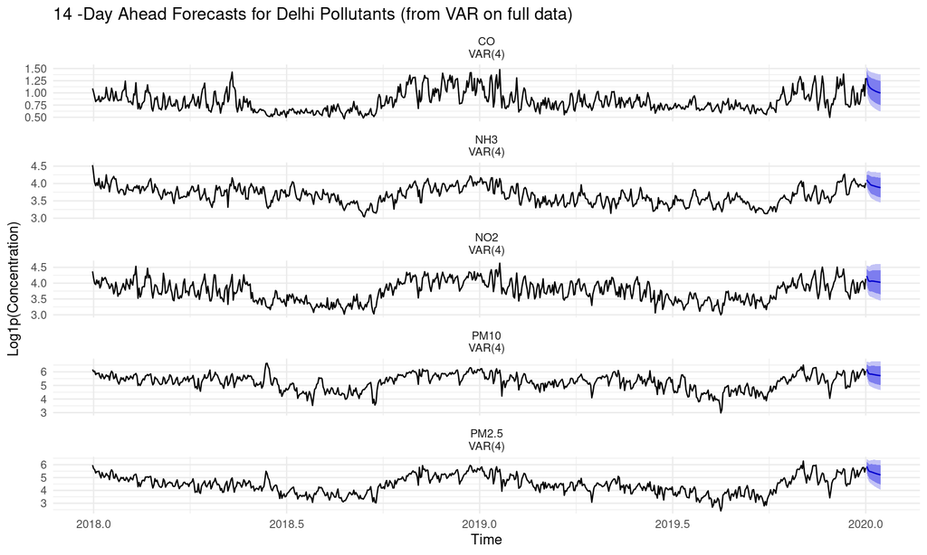

```r
fc_all_pollutants <- forecast::forecast(var_model, h = forecast_horizon)

autoplot(fc_all_pollutants) +
  labs(
    title = paste(forecast_horizon, "-Day Ahead Forecasts for Delhi Pollutants (from VAR on full data)"),
    x = "Time", y = "Log1p(Concentration)"
  ) +
  theme_minimal()
```

# 8. Summary of Key Findings and Conclusion

This analysis of Delhi’s air quality data (2018-2019) for key pollutants (PM2.5, PM10, NO2, CO, and NH3) reveals several key insights:

The daily mean concentrations of these pollutants, after log1p transformation to stabilize variance, were found to be stationary. This allowed for the direct modeling of their interdependencies using a Vector Autoregressive Moving Average (VARMA(1,1)) model. This model successfully captured the complex linear relationships, indicating significant own-lag effects and cross-pollutant dynamics, highlighting the interconnected nature of these air pollutants.

Granger causality tests indicated, for instance, that past values of NO2 have significant predictive power for the other pollutants in the system (PM2.5, PM10, CO, and NH3, p-value ≈ 0.033 for the joint test). Further investigation via Forecast Error Variance Decomposition (FEVD) suggested that unexpected shocks in PM2.5 contribute substantially to the forecast uncertainty of other pollutants, underscoring its central role in the system’s dynamics.

Overall, the VARMA framework proved effective for characterizing the mean dynamics and generating forecasts, while specialized tests and decompositions helped quantify the influence and predictive power among the selected pollutants. This comprehensive approach provides a valuable understanding of Delhi’s air pollution dynamics, which can inform further research and potential mitigation strategies.